# 1999-2022年全美男女在肺癌中的发病率趋势

# 预处理

选择镜像

导入文件的包

```r
install.packages("rlang", dependencies = T)
install.packages("data.table")
install.packages("tidyverse")
install.packages("patchwork")
```

```r
library(data.table)
library(tidyverse)
library(patchwork)
```

# 1 数据处理

## 1.1 数据读取

```r
data_sex <- "../lung_cancer_data/BYSITE.TXT"
df <- data.table::fread(file = data_sex)
```

## 1.2 数据筛选

查看数据集包含的组别：

```r
names(df)
```

```
##  [1] "YEAR"                  "RACE"                  "SEX"
##  [4] "SITE"                  "EVENT_TYPE"            "AGE_ADJUSTED_CI_LOWER"
##  [7] "AGE_ADJUSTED_CI_UPPER" "AGE_ADJUSTED_RATE"     "COUNT"
## [10] "POPULATION"
```

全部需要讨论。

①用于对基础目标数据的分析：“YEAR”“RACE”“SEX”“SITE”“EVENT_TYPE”

②用于去除年龄的影响，故保留年龄标化率：“AGE_ADJUSTED_CI_LOWER”“AGE_ADJUSTED_CI_UPPER” “AGE_ADJUSTED_RATE”

③用于讨论实际发病率：“COUNT”“POPULATION”

### 1.2.1 关键变量分布探查

查找前5列数据包含的元素，以确定后续筛选对象。

```r
data_col_element <- list()
for (i in names(df)[1:5]) {
  data_col_element[[i]] <- unique(df[[i]])
}
```

YEAR中包含”2018-2022”“2019-2023”,需去除。

### 1.2.2 筛选数据为画男女发病率做准备

#### 1.2.2.1 筛选数据

- YEAR：筛序出1999-2023年的数据
- RACE：筛选出“All Races”，即全美国的数据
- SEX：筛选出“Male”, “Female”
- SITE：筛选出”Lung and Bronchus”
- EVENT_TYPE：筛选出“Incidence”

```r
# 检查YEAR的数据类型
str(df[[1]])   #结果为 chr
```

```
##  chr [1:68945] "1999" "1999" "2000" "2000" "2001" "2001" "2002" "2002" ...
```

```r
# 将YEAR的字符串转换为数值型
df[[1]] <- as.numeric(df[[1]])
# 其余组别数据都为chr，且无需转换
str(df[[1]])
```

```
##  num [1:68945] 1999 1999 2000 2000 2001 ...
```

```r
# 进行筛选
clean_sex1 <- df %>%
  filter(YEAR >= 1999 & YEAR <= 2023, RACE == "All Races",SEX %in% c("Male", "Female"), SITE == "Lung and Bronchus", EVENT_TYPE =="Incidence" )
```

```r
reason_fault1 <- list()
for(i in names(clean_sex1)){
  reason_fault1[[i]] <- unique(clean_sex1[[i]])
}
```

发现clean_sex1$YEAR中缺少2023年数据，因此返回df中确认是否确实没有记录该数据。

```r
reason_fault2 <- df %>%
  filter(YEAR == 2023, SITE == "Lung and Bronchus")
```

结果发现2023年的发病率未被记录，仅包含死亡率的数据。

因此，将本次研究调整为分析1999-2022年的数据。

## 1.3 数据清洗

### 1.3.1 处理缺失值

```r
sum(is.na(clean_sex1))
```

```
## [1] 0
```

sum为0，无缺失值，故无需处理。

### 1.3.2 按照年份对数据集进行排序

根据年份按照从小到大的排列方式：

```r
class(clean_sex1[[1]])
```

```
## [1] "numeric"
```

```r
clean_sex2 <- clean_sex1 %>%
  arrange(YEAR)
```

# 2 用ggpolt2画图

## 2.1 确认数据类型

```r
str(clean_sex2)
```

```
## Classes 'data.table' and 'data.frame':   48 obs. of  10 variables:
##  $ YEAR                 : num  1999 1999 2000 2000 2001 ...
##  $ RACE                 : chr  "All Races" "All Races" "All Races" "All Races" ...
##  $ SEX                  : chr  "Female" "Male" "Female" "Male" ...
##  $ SITE                 : chr  "Lung and Bronchus" "Lung and Bronchus" "Lung and Bronchus" "Lung and Bronchus" ...
##  $ EVENT_TYPE           : chr  "Incidence" "Incidence" "Incidence" "Incidence" ...
##  $ AGE_ADJUSTED_CI_LOWER: chr  "53.5" "93.4" "53.9" "91.6" ...
##  $ AGE_ADJUSTED_CI_UPPER: chr  "54.3" "94.5" "54.6" "92.7" ...
##  $ AGE_ADJUSTED_RATE    : chr  "53.9" "94.0" "54.2" "92.1" ...
##  $ COUNT                : chr  "81954" "109724" "83529" "109402" ...
##  $ POPULATION           : int  140394214 135067134 141865770 136692444 143603977 138511984 144919222 139847290 147679036 142428897 ...
##  - attr(*, ".internal.selfref")=<externalptr>
```

```r
#需把AGE_ADJUSTED_CI_LOWER和AGE_ADJUSTED_CI_UPPER变成数值型
clean_sex2[[6]] <- as.numeric(clean_sex2[[6]])
clean_sex2[[7]] <- as.numeric(clean_sex2[[7]])
clean_sex2[[8]] <- as.numeric(clean_sex2[[8]])
```

## 2.2 画出男女发病率的图

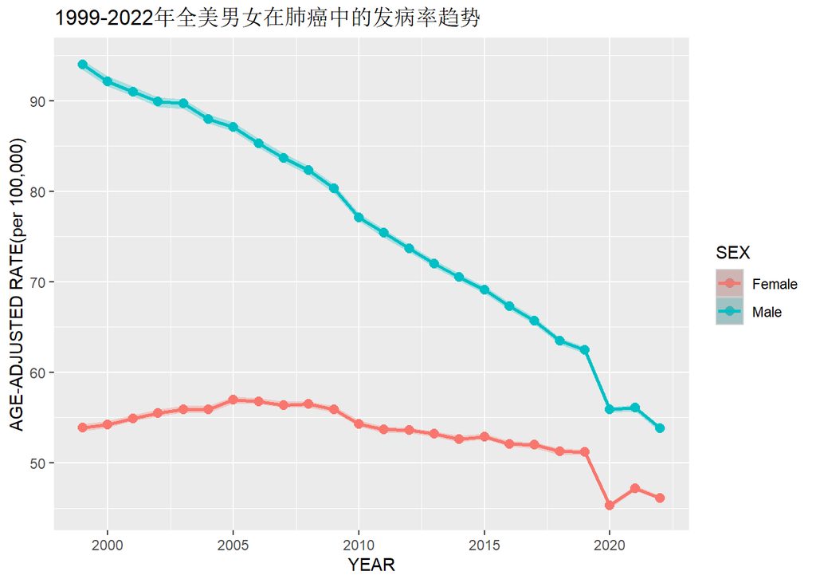

```r
result1 <- ggplot(data = clean_sex2,
                 mapping = aes(x = YEAR, y = AGE_ADJUSTED_RATE, colour = SEX, group = SEX))+
# geom
  geom_point(size = 2.5)+
  geom_ribbon(aes(ymax = AGE_ADJUSTED_CI_UPPER, ymin = AGE_ADJUSTED_CI_LOWER, fill = SEX, group = SEX), alpha = 0.3, colour = NA)+
  geom_line(aes(group = SEX), size = 1)+
  geom_smooth(stat = "identity")+
# scale
  labs(title = "1999-2022年全美男女在肺癌中的发病率趋势", x = "YEAR", y = "AGE-ADJUSTED RATE(per 100,000)")
result1
```

## 2.3 画出男女发病率差距图（差距量化）

### 2.3.1 筛选数据并添加gender_gap

筛选目标2 添加： - gender_gap：用于分析男女发病率的差距（male - female)

```r
creat_list <- clean_sex2 %>%
  select(YEAR, SEX, AGE_ADJUSTED_RATE) %>%
  pivot_wider(names_from = SEX, values_from = AGE_ADJUSTED_RATE) %>%
  mutate(gender_gap = Male - Female)
```

### 2.3.2 可视化

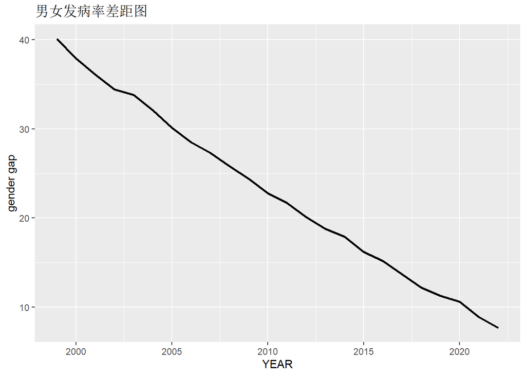

```r
result2 <- ggplot(creat_list, aes(x = YEAR, y = gender_gap))+
  geom_line(size = 1)+
    labs(title = "男女发病率差距图", x = "YEAR", y = "gender gap")
result2
```

## 2.4 合并两张图

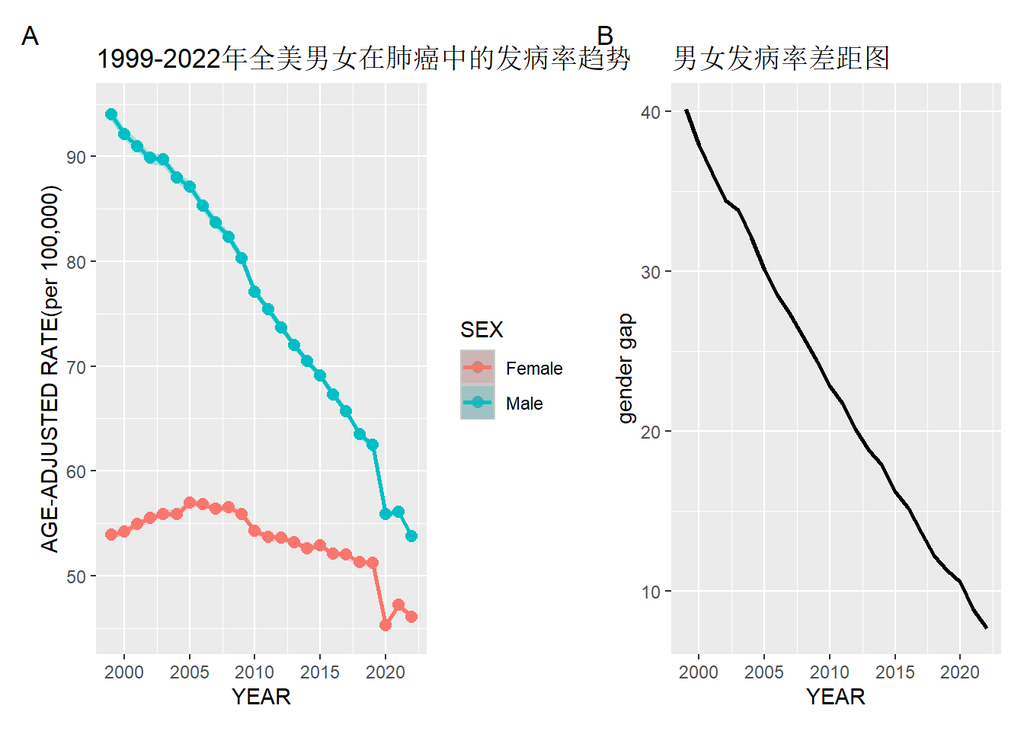

```r
p_come <- (result1 + result2) +
  plot_annotation(tag_levels = "A")
p_come
```

# 3 数据分析

## 3.1 添加标准误至clean_sex3中，并且按SEX分组排序

```r
clean_sex3 <- clean_sex2 %>%
  mutate(SE = (AGE_ADJUSTED_CI_UPPER - AGE_ADJUSTED_CI_LOWER)/3.92) %>%
  group_by(SEX) %>%
  arrange(YEAR, .by_group = T) %>%
  ungroup()
```

## 3.2 读出clean_sex3的表格，放至joinpoint中分析

```r
write.csv(clean_sex3, file = "../lung_cancer_data/write_sex.csv", row.names = F)
```

## 3.3 算出1999-2005年的效应量

```r
female_data <- subset(clean_sex3, SEX == "Female" & YEAR >= 1999 & YEAR <= 2005)
fit <- lm(AGE_ADJUSTED_RATE ~ YEAR, female_data)
beta <- coef(fit)["YEAR"]# 算线性回归的回归斜率β
SD_ASR <- sd(female_data$AGE_ADJUSTED_RATE)# 算SD
es <- beta / SD_ASR
```